# # SICSS Norrköping 2025: Network Analysis (SOLUTIONS)

Author

Alexandra Rottenkolber

Published

June 15, 2025

## 1 Introduction & getting started

Welcome to the practical part of the network analysis day! In this session, you will get an introduction to how to represent a network with the help of R (or Python, see other script), how to calculate basic network descriptives (on the micro, meso and macro level), and how to put on the “network thinking hat”. You are invited to work through the exercise sheet on your own/in groups, and with the help of mine and Carl where needed. If you are already familiar with some aspects of the lab, feel free to jump over certain sections or go straight to the exercise part.

**Learning goals for this workshop**

1. Introduction
- Represent a network in R (with IGRAPH)
- Create a graph from scratch (add nodes, edges, attributes)
- Visualise it
2. Basic network descriptives
- macro-level descriptives
- meso-level descriptives
- micro-level descriptives
3. Network thinking
- Majority illusion
- Friendship paradox

### 1.1 Introduction

**Getting started.** First, we need to install the most important packages for network analysis in R.  
There are plenty of R packages for network analysis available, which are tailored to perform different types of analysis. The most important ones for the beginning are

- “sna”
- “igraph”
- “network”
- “ggraph” for visualisations (uses ggplot2)
- “egor” for ego-nets (uses igraph objects)
- “netseg” for assortativity patterns, homophily, segregation, within-group mixing, etc.
- “isnar”
- “networkdata” a large sample of networks in igraph format (to install network data, see: https://github.com/schochastics/networkdata)
- “igraphdata” several network datasets
- “tidygraph” for tidy manipulation of igraph objects
- etc.

To install the packages you need, you can simply type the name of the package within `install.packages("")`, e.g. `install.packages(c('sna','igraph'))` `install.packages("here")`

### 1.2 Creating a graph object

The most widely used R packages for (simply) network analysis are called `sna` and `igraph`. To create a graph object, SNA works with matrices as inputs, while this is not the case for IGRAPH. IGRAPH requires igraph objects as inputs. You can find information on the basic IGRAPH datatypes [here](https://igraph.org/c/doc/igraph-Basic.html).

```r
# In SNA, the basic element is the MATRIX
mtx <- matrix(c(0, 1, 0, 0, 0, 0, 0,
                1, 0, 1, 1, 1, 0, 0,
                1, 1, 0, 0, 0, 0, 0,
                0, 1, 0, 0, 1, 0, 0,
                0, 1, 0, 1, 0, 1, 1,
                0, 0, 0, 0, 1, 0, 1,
                0, 0, 0, 0, 1, 1, 0),
              nrow=7,
              ncol=7,
              byrow=TRUE)
mtx
```

```
     [,1] [,2] [,3] [,4] [,5] [,6] [,7]
[1,]    0    1    0    0    0    0    0
[2,]    1    0    1    1    1    0    0
[3,]    1    1    0    0    0    0    0
[4,]    0    1    0    0    1    0    0
[5,]    0    1    0    1    0    1    1
[6,]    0    0    0    0    1    0    1
[7,]    0    0    0    0    1    1    0
```

```r
class(mtx) # An array is a n-dimensional object
```

```
[1] "matrix" "array"
```

```r
dim(mtx) # Shows dimensions of the matrix. Here, we have a 7x7 matrix.
```

```
[1] 7 7
```

```r
# Usually, we would like to label the dimensions
dimnames(mtx) <- list(c('Kira','Amaya','Rohan', 'Robin', 'Hanna', 'Adam', 'Igor'),c('Kira','Amaya','Rohan','David', 'Hanna', 'Adam', 'Igor'))
mtx
```

```
      Kira Amaya Rohan David Hanna Adam Igor
Kira     0     1     0     0     0    0    0
Amaya    1     0     1     1     1    0    0
Rohan    1     1     0     0     0    0    0
Robin    0     1     0     0     1    0    0
Hanna    0     1     0     1     0    1    1
Adam     0     0     0     0     1    0    1
Igor     0     0     0     0     1    1    0
```

```r
# We can access each element of a matrix separately
mtx[1,2] # first row, second column
```

```
[1] 1
```

```r
mtx['Adam','Igor'] # sixth row, seventh column
```

```
[1] 1
```

```r
# And we can replace elements by assigning a new value
mtx[3,1] <- 0 # Assigns 0 to the element in the 3rd row, 1st column
mtx
```

```
      Kira Amaya Rohan David Hanna Adam Igor
Kira     0     1     0     0     0    0    0
Amaya    1     0     1     1     1    0    0
Rohan    0     1     0     0     0    0    0
Robin    0     1     0     0     1    0    0
Hanna    0     1     0     1     0    1    1
Adam     0     0     0     0     1    0    1
Igor     0     0     0     0     1    1    0
```

```r
# In social network analysis, the diagonal of a matrix is often set to NA. If done so it indicates that self-loops cannot exist per definition and aren't just not present in the data.
diag(mtx) # Returns the elements in positions (1,1),... (n,n)
```

```
[1] 0 0 0 0 0 0 0
```

```r
diag(mtx) <- NA
mtx
```

```
      Kira Amaya Rohan David Hanna Adam Igor
Kira    NA     1     0     0     0    0    0
Amaya    1    NA     1     1     1    0    0
Rohan    0     1    NA     0     0    0    0
Robin    0     1     0    NA     1    0    0
Hanna    0     1     0     1    NA    1    1
Adam     0     0     0     0     1   NA    1
Igor     0     0     0     0     1    1   NA
```

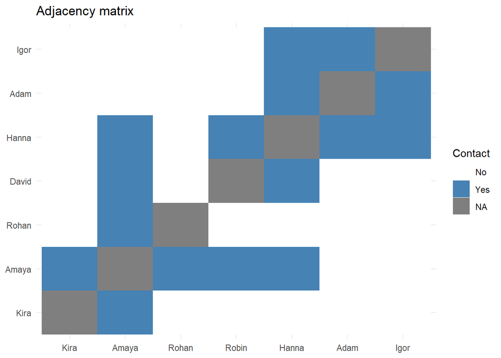

```r
mtx |>
  reshape2::melt() |>
ggplot2::ggplot(ggplot2::aes(x=Var1,y=Var2,fill=value |> as.factor()))+
  ggplot2::geom_tile()+
  ggplot2::labs(title='Adjacency matrix', x=NULL, y=NULL)+
  ggplot2::scale_fill_manual(values=c('white','steelblue', "lightgray"), name='Contact', labels=c('No','Yes', NA))+
  ggplot2::theme_minimal()
```

This matrix could already be interpreted as representing a network (This format is called a network’s *adjacency martix*.). Say the values indicate whether a person i (in the rows) is in contact with another person (in the columns) on a regular basis. How would you interpret the network?

#### 1.2.1 Visualising a network

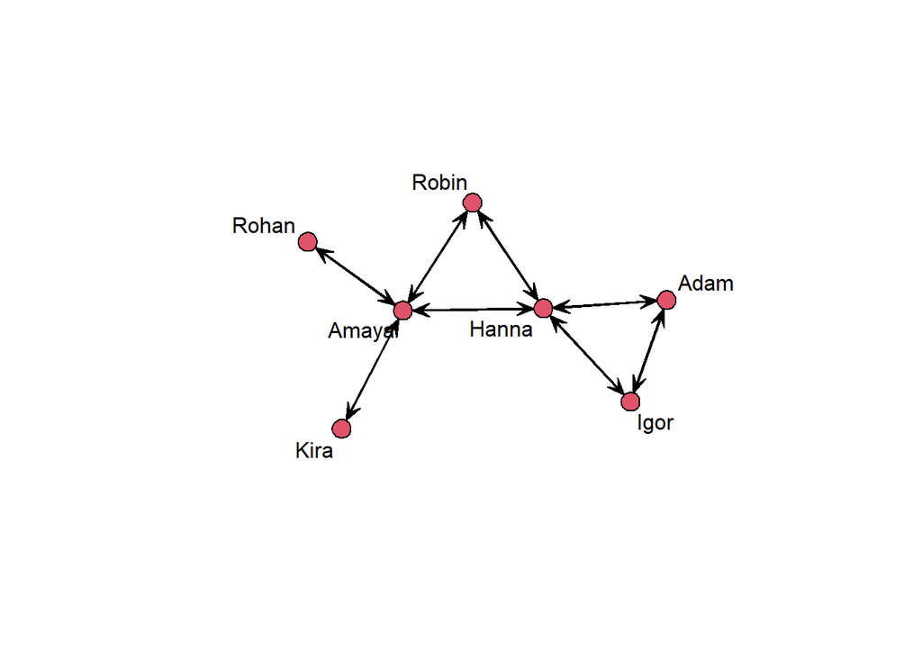

```r
gplot(mtx,displaylabels = TRUE)
```

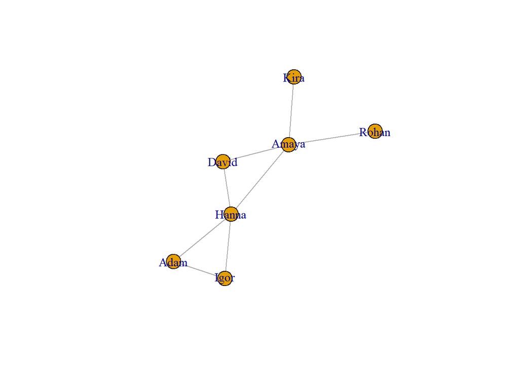

```r
#plot.igraph(mtx) # this will throw an error
grph <- mtx |>
  graph_from_adjacency_matrix(mode='undirected') # create a graph object from our martix
# Using the igraph library
grph |>
  plot.igraph()
```

```
Using "stress" as default layout
```

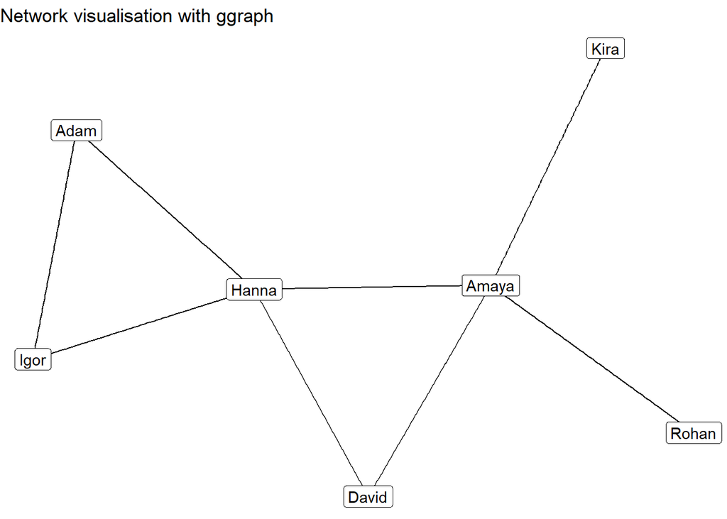

```r
# Using the ggraph library
set.seed(42)
grph |>
  ggraph() +
  geom_edge_link() +
  geom_node_label(aes(label=name)) +
  theme_void() +
  ggtitle("Network visualisation with ggraph")
```

#### 1.2.2 Adding nodes and edges

There are several ways how to create a graph from scratch. Either you set up an adjacency matrix as shown above. Or you use an edge list as an input or add nodes and edges separately, as shown below.

```r
# use and edge list as an input for an undirected graph
g_undirected <- graph_from_literal(1-2, 2-3, 2-4, 2-5, 4-5, 5-6, 5-7, 6-7)
g_undirected
```

```
IGRAPH 6aeea8a UN-- 7 8 --
+ attr: name (v/c)
+ edges from 6aeea8a (vertex names):
[1] 1--2 2--3 2--4 2--5 4--5 5--6 5--7 6--7
```

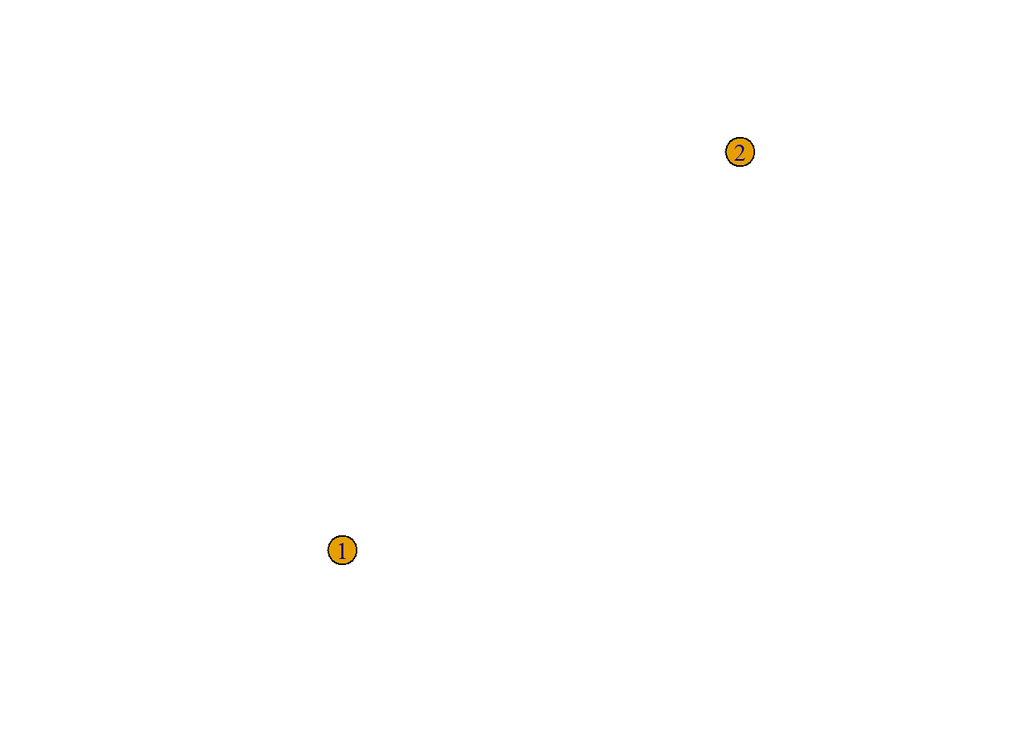

```r
# or start with an empty graph and add nodes and edges separately
g_undirected_2 <- make_empty_graph(directed = FALSE) # empty graph
g_undirected_2 <- g_undirected_2 |> add_vertices(2) # add nodes
plot(g_undirected_2)
```

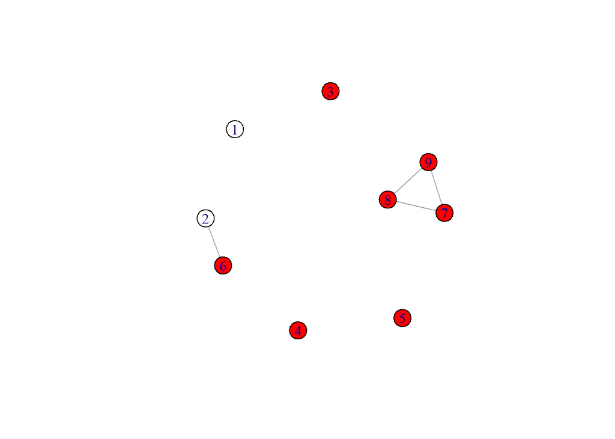

```r
# you can also use the pipe operator and do several steps at once
g_undirected_2 <- g_undirected_2 |>
  add_vertices(7, color = "red") |>  # you can input attributes in this statement, too
  add_edges(c(2,6, 7,8, 7,9, 8,9))
plot(g_undirected_2)
```

```r
# For a directed graph:
# use (-+, +-, or ++) to indicate the arrow ends (with a +)
g_directed <- graph_from_literal(1+-2, 2-+3, 2+-4, 2++5, 4+-5, 5-+6, 5++7, 6++7)  # plus sign captures the arrow end
g_directed
```

```
IGRAPH 6af325c DN-- 7 11 --
+ attr: name (v/c)
+ edges from 6af325c (vertex names):
 [1] 2->1 2->3 2->5 4->2 5->2 5->4 5->6 5->7 6->7 7->5 7->6
```

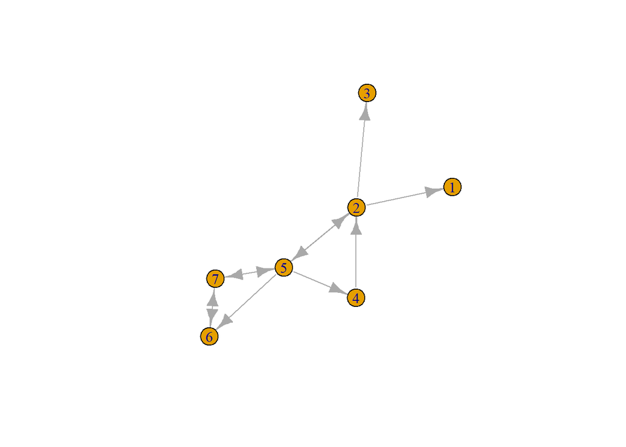

```r
plot(g_directed)
```

```r
# With V() and E() the nodes (vertices) and ties (edges) can be accessed.
V(g_directed) # nodes/vertices
```

```
+ 7/7 vertices, named, from 6af325c:
[1] 1 2 3 4 5 6 7
```

```r
E(g_directed) # ties/edges
```

```
+ 11/11 edges from 6af325c (vertex names):
 [1] 2->1 2->3 2->5 4->2 5->2 5->4 5->6 5->7 6->7 7->5 7->6
```

```r
# Let's rename the nodes
V(g_undirected)$name <- c('Kira','Amaya','Rohan', 'Robin', 'Hanna', 'Adam', 'Igor')
g_undirected
```

```
IGRAPH 6aeea8a UN-- 7 8 --
+ attr: name (v/c)
+ edges from 6aeea8a (vertex names):
[1] Kira --Amaya Amaya--Rohan Amaya--Robin Amaya--Hanna Robin--Hanna
[6] Hanna--Adam  Hanna--Igor  Adam --Igor
```